# Homework_3

Gülşah Akçakır - IE582 - Fall 2018

19 Kasım 2018

# Task 1

We were given datasets providing observations from 8 different gesture classes. One instance from each class have plotted for visualization (in terms of both acceleration and velocity):

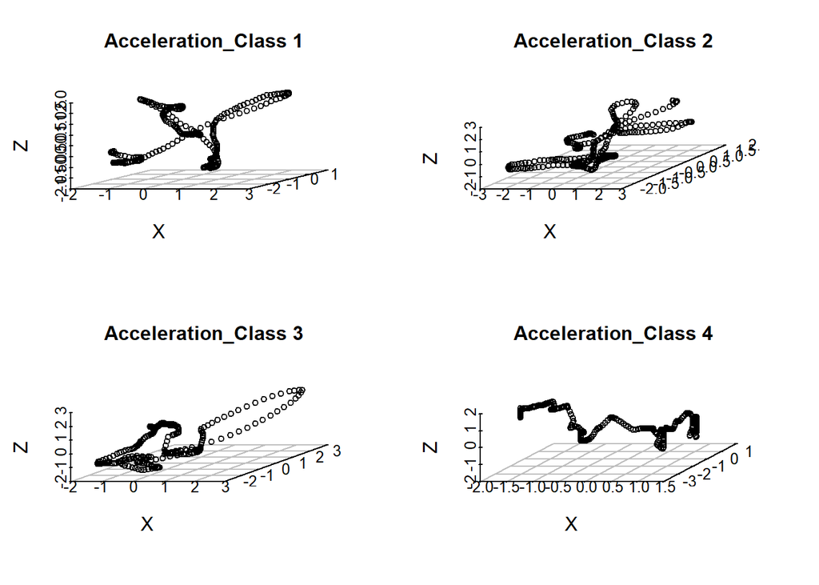

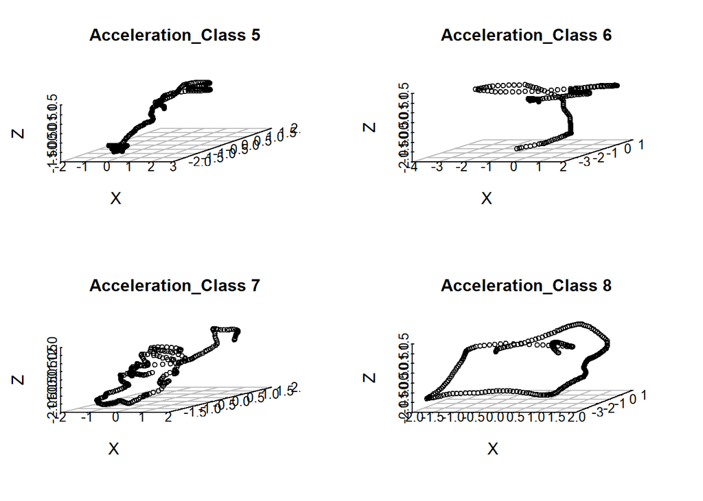

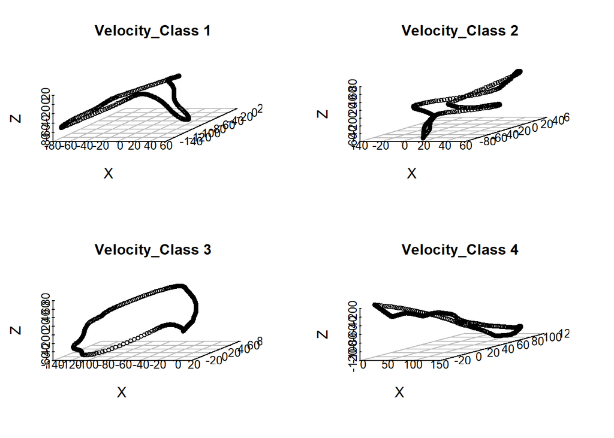

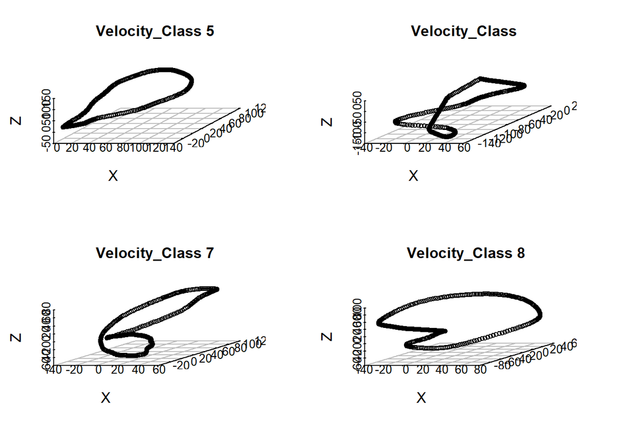

Results obtained can be seen below:

```
##     Klev      Accu
##  1:    1 0.9437500
##  2:    2 0.9361607
##  3:    3 0.9437500
##  4:    4 0.9372768
##  5:    5 0.9379464
##  6:    6 0.9348214
##  7:    7 0.9375000
##  8:    8 0.9343750
##  9:    9 0.9299107
## 10:   10 0.9274554
## 11:   11 0.9265625
## 12:   12 0.9254464
## 13:   13 0.9247768
## 14:   14 0.9236607
## 15:   15 0.9227679
## 16:   16 0.9209821
## 17:   17 0.9205357
## 18:   18 0.9194196
## 19:   19 0.9176339
## 20:   20 0.9160714
```

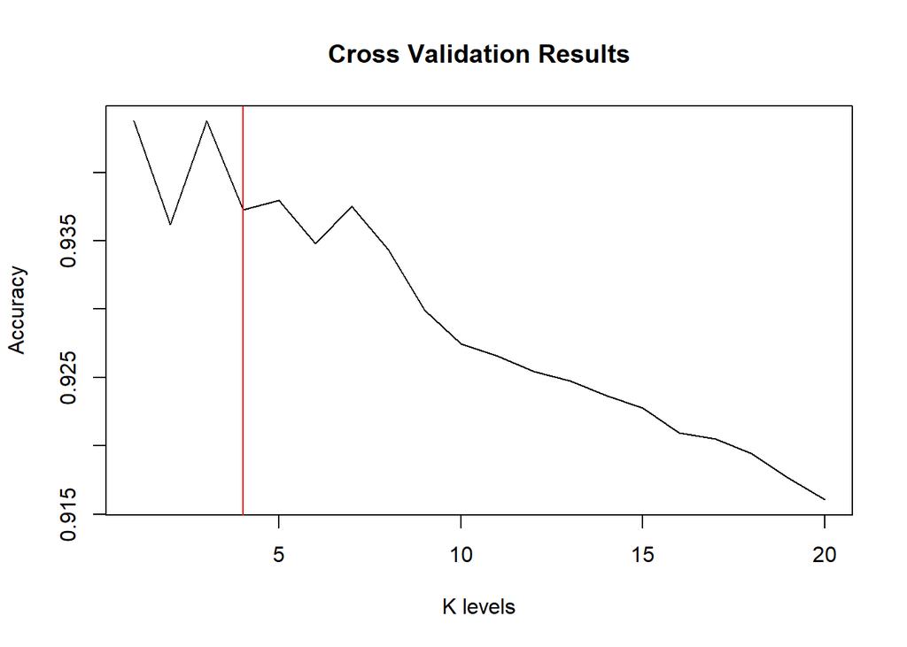

In addition to confusion matrix presenting the obtained results, runtime of the algorithm and accuracy of the classifier can be seen below.

```r
conMat <- confusionMatrix(factor(testclass), factor(prediction))
conMat$table
```

```
##           Reference
## Prediction   1   2   3   4   5   6   7   8
##          1 429   0   0   3   0   5   0   0
##          2   1 449   0   0   0   0   2   0
##          3   0   0 408   0  19  22   5   0
##          4   4   0   0 373  60   7   0   6
##          5   3   0   7   2 420   1   0   0
##          6   7   0   3  14  31 393   1   0
##          7   0   0   4   0   0   0 443   0
##          8   0   0   0   2   1   0   0 457
```

```r
conMat$overall["Accuracy"]
```

```
##  Accuracy
## 0.9413735
```

```r
time.taken
```

```
## Time difference of 31.79868 secs
```

To see whole codes related to Task 1, see Appendix A.

# Task 2

We were asked to train a logistic regression model on the given ECG data using fused lasso penalties.

The given series:

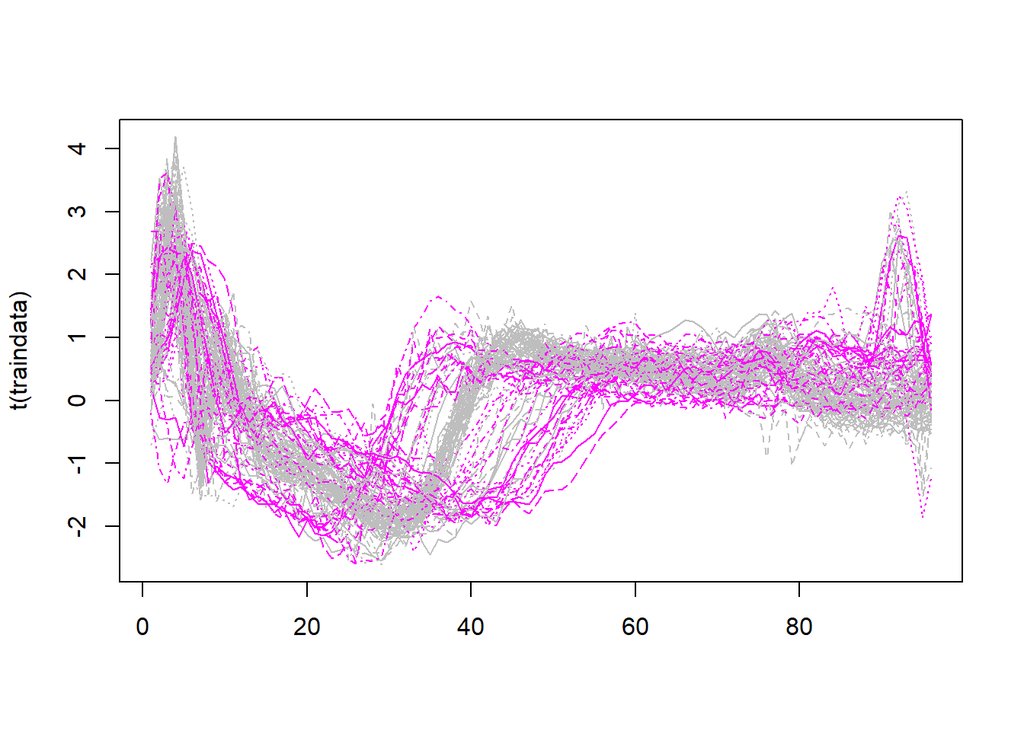

lqa package which has cross-validation included, selected to obtain the model with best parameters.

```r
cvFused2=cv.lqa(trainclass,traindata,lambda.candidates = lambdas, intercept = FALSE, standardize = T,
               family=gaussian(), penalty.family=fused.lasso ,n.fold=10,loss.func = "aic.loss")
```

The model with best coefficients:

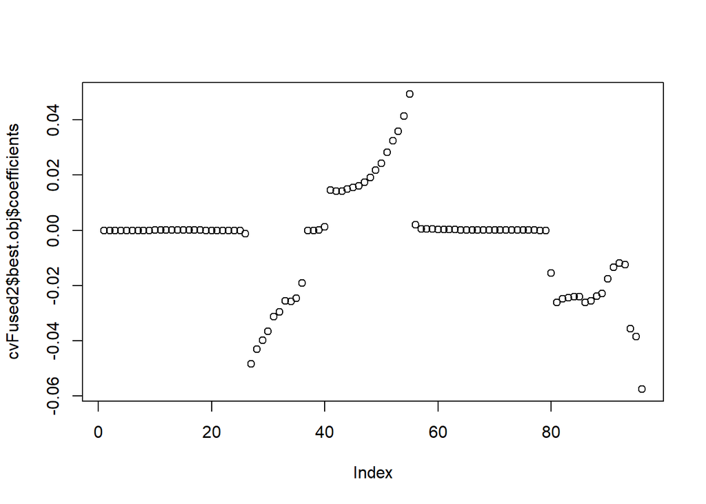

```r
plot(cvFused2$best.obj$coefficients)
```

Then classes of test data predicted using the model obtained.

```r
prediction <- predict.lqa (cvFused2$best.obj, new.x = testdata)
```

Plot of predicted and real classes given below:

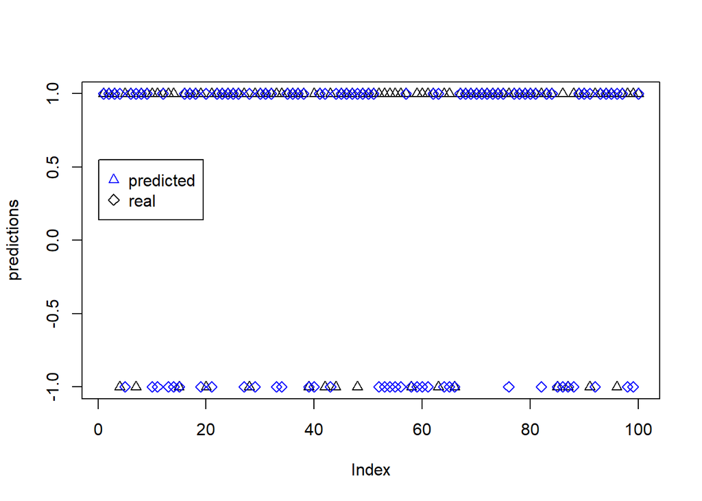

The confusion matrix :

```r
conMat <- confusionMatrix(factor(testclass), factor(predictions))
conMat$table
```

```
##           Reference
## Prediction -1  1
##         -1  6 30
##         1  10 54
```

Time series transformed by taking the difference between consecutive time series observations and similar applications applied on new dataset.

```r
transformed_train <- traindata

for (i in 1:(dim(traindata)[2]-1)) {
  transformed_train[,i] = (traindata[,(i+1)] - traindata[,i])
}

transformed_test <- testdata

for (i in 1:(dim(traindata)[2]-1)) {
  transformed_test[,i] = (testdata[,(i+1)] - testdata[,i])
}
```

The confusion matrix:

```
##           Reference
## Prediction -1  1
##         -1  5 31
##         1  16 48
```

To see whole codes related to Task 2, see Appendix B.

## APPENDIX A

```r
setwd('C:\\Users\\gulsa\\Desktop\\2018-2019 Güz\\IE582')

fname_X='homeworks/Homework_3/train/uWaveGestureLibrary_X_TRAIN' # data path
fname_Y='homeworks/Homework_3/train/uWaveGestureLibrary_Y_TRAIN'
fname_Z='homeworks/Homework_3/train/uWaveGestureLibrary_Z_TRAIN'

train_X <- as.matrix(read.table(fname_X))  # read data
train_Y <- as.matrix(read.table(fname_Y))
train_Z <- as.matrix(read.table(fname_Z))

trainclass=train_X[,1]

train_X=train_X[,-1]
train_Y=train_Y[,-1]
train_Z=train_Z[,2:ncol(train_Z)]

velocity_X <- train_X
for (i in 1:ncol(train_X)) {
velocity_X[i,] <- cumsum(train_X[i,])
}

velocity_Y <- train_Y
for (i in 1:ncol(train_Y)) {
  velocity_Y[i,] <- cumsum(train_Y[i,])
}

velocity_Z <- train_Z
for (i in 1:ncol(train_Z)) {
  velocity_Z[i,] <- cumsum(train_Z[i,])
}

library("scatterplot3d")
par(mfrow=c(4,4))
scatterplot3d(train_X[11,],train_Y[11,],train_Z[11,],box = F) #1
scatterplot3d(train_X[15,],train_Y[15,],train_Z[15,],box = F) #2
scatterplot3d(train_X[4,],train_Y[4,],train_Z[4,],box = F)    #3
scatterplot3d(train_X[5,],train_Y[5,],train_Z[5,],box = F)    #4
scatterplot3d(train_X[3,],train_Y[3,],train_Z[3,],box = F)    #5
scatterplot3d(train_X[1,],train_Y[1,],train_Z[1,],box = F)    #6
scatterplot3d(train_X[7,],train_Y[7,],train_Z[7,],box = F)    #7
scatterplot3d(train_X[6,],train_Y[6,],train_Z[6,],box = F)    #8

par(mfrow=c(4,4))
scatterplot3d(velocity_X[11,],velocity_Y[11,],velocity_Z[11,],box = F) #1
scatterplot3d(velocity_X[15,],velocity_Y[15,],velocity_Z[15,],box = F) #2
scatterplot3d(velocity_X[4,],velocity_Y[4,],velocity_Z[4,],box = F)    #3
scatterplot3d(velocity_X[5,],velocity_Y[5,],velocity_Z[5,],box = F)    #4
scatterplot3d(velocity_X[3,],velocity_Y[3,],velocity_Z[3,],box = F)    #5
scatterplot3d(velocity_X[1,],velocity_Y[1,],velocity_Z[1,],box = F)    #6
scatterplot3d(velocity_X[7,],velocity_Y[7,],velocity_Z[7,],box = F)    #7
scatterplot3d(velocity_X[6,],velocity_Y[6,],velocity_Z[6,],box = F)    #8

combined_data <- cbind(train_X,train_Y,train_Z)

#Determination of k with CV
require(FNN)
require(glmnet)
require(TunePareto)
require(data.table)

k_levels=c(1:20)
nofReplications=5
nFolds=10
indices=generateCVRuns(trainclass,nofReplications,nFolds,stratified=TRUE)

cvresult=data.table()

for(i in 1:nofReplications) {
  thisReplication=indices[[i]]
  for(j in 1:nFolds){
    testindices=thisReplication[[j]]

    cvtrain=combined_data[-testindices,]
    cvtest=combined_data[testindices,]

    for(y in 1:length(k_levels)){
      param_k=k_levels[y]
      predict_knn=knn(cvtrain, cvtest,trainclass[-testindices], k = param_k)
      cvresult=rbind(cvresult,data.table(Replication=i,Fold=j,Method='knn',Klev=param_k,TestId=testindices,
                                         Predictions=as.numeric(as.character(predict_knn)),Real=trainclass[testindices]))
    }
  }
}


a <- cvresult[,list(Accu=mean(Predictions==Real)),by=list(Klev)]

plot(a$Klev,a$Accu,type = "l",  xlab = "K levels", ylab = "Accuracy", main = "Cross Validation Results" )
abline(v=4, col="red")

#Prediction
fname_test_X='homeworks/Homework_3/test/uWaveGestureLibrary_X_TEST' # data path
fname_test_Y='homeworks/Homework_3/test/uWaveGestureLibrary_Y_TEST'
fname_test_Z='homeworks/Homework_3/test/uWaveGestureLibrary_Z_TEST'

test_X <- as.matrix(read.table(fname_test_X))
test_Y <- as.matrix(read.table(fname_test_Y))
test_Z <- as.matrix(read.table(fname_test_Z))

testclass=test_X[,1]

test_X=test_X[,-1]
test_Y=test_Y[,-1]
test_Z=test_Z[,2:ncol(test_Z)]

combined_test <- cbind(test_X,test_Y,test_Z)

require(class)
start.time <- Sys.time()

prediction <- knn(train= combined_data, test = combined_test, cl=trainclass, k=4)

end.time <- Sys.time()
time.taken <- end.time - start.time

library(caret)
conMat <- confusionMatrix(factor(testclass), factor(prediction))
conMat$table
conMat$overall["Accuracy"]

time.taken
```

## APPENDIX B

```r
packageurl <- "http://cran.r-project.org/src/contrib/Archive/lqa/lqa_1.0-3.tar.gz"
install.packages(packageurl, repos=NULL, type="source")

require(lqa)
set.seed(223)
fname='C:\\Users\\gulsa\\Desktop\\2018-2019 Güz\\IE582\\Rfiles\\kNN_Classification\\ecgTRAIN' # data path
traindata <- as.matrix(read.table(fname))  # read data into a matrix named traindata
#first column is the class variable
trainclass=traindata[,1] # takes -1 and 1
#drop first column
traindata=traindata[,2:ncol(traindata)]

#plot the series overlaid
matplot(t(traindata),type="l",col=trainclass+7)

#generating arbitrary lambda sequences
lambdaseq <- exp (seq (-4, 4, length = 10))

lambdas=list(1,lambdaseq)


cvFused2=cv.lqa(trainclass,traindata,lambda.candidates = lambdas, intercept = FALSE, standardize = T,
               family=gaussian(), penalty.family=fused.lasso ,n.fold=10,loss.func = "aic.loss")

#check the coefficients of the best model
plot(cvFused2$best.obj$coefficients)

fname2='C:\\Users\\gulsa\\Desktop\\2018-2019 Güz\\IE582\\Rfiles\\kNN_Classification\\ecgTEST'
testdata <- as.matrix(read.table(fname2))  # read data into a matrix named traindata
#first column is the class variable
testclass=testdata[,1]
#drop first column
testdata=testdata[,2:ncol(testdata)]

prediction <- predict.lqa (cvFused2$best.obj, new.x = testdata)

str(prediction)
fitted <- prediction$lqa.obj$fitted.values
predictions <- ifelse(fitted > 0.0,1,-1)
plot(predictions, ylim=c(-1,1))
points(testclass, col="blue", pch =5)


library(caret)
conMat <- confusionMatrix(factor(testclass), factor(predictions))
conMat$table


###################################################################################
transformed_train <- traindata

for (i in 1:(dim(traindata)[2]-1)) {
  transformed_train[,i] = (traindata[,(i+1)] - traindata[,i])
}

transformed_test <- testdata

for (i in 1:(dim(traindata)[2]-1)) {
  transformed_test[,i] = (testdata[,(i+1)] - testdata[,i])
}

cvFused3=cv.lqa(trainclass,transformed_train,lambda.candidates = lambdas, intercept = FALSE, standardize = T,
                family=gaussian(), penalty.family=fused.lasso ,n.fold=10,loss.func = "aic.loss")

plot(cvFused3$best.obj$coefficients)

prediction_transformed <- predict.lqa (cvFused3$best.obj, new.x = transformed_test)

str(prediction)
fitted_transformed <- prediction_transformed$lqa.obj$fitted.values
predictions_transformed <- ifelse(fitted_transformed > 0.0,1,-1)
plot(predictions_transformed, ylim=c(-1,1))
points(testclass, col="blue", pch =5)


library(caret)
conMat_transformed <- confusionMatrix(factor(testclass), factor(predictions_transformed))
conMat_transformed$table
```